# Project 2 - Thera Bank III

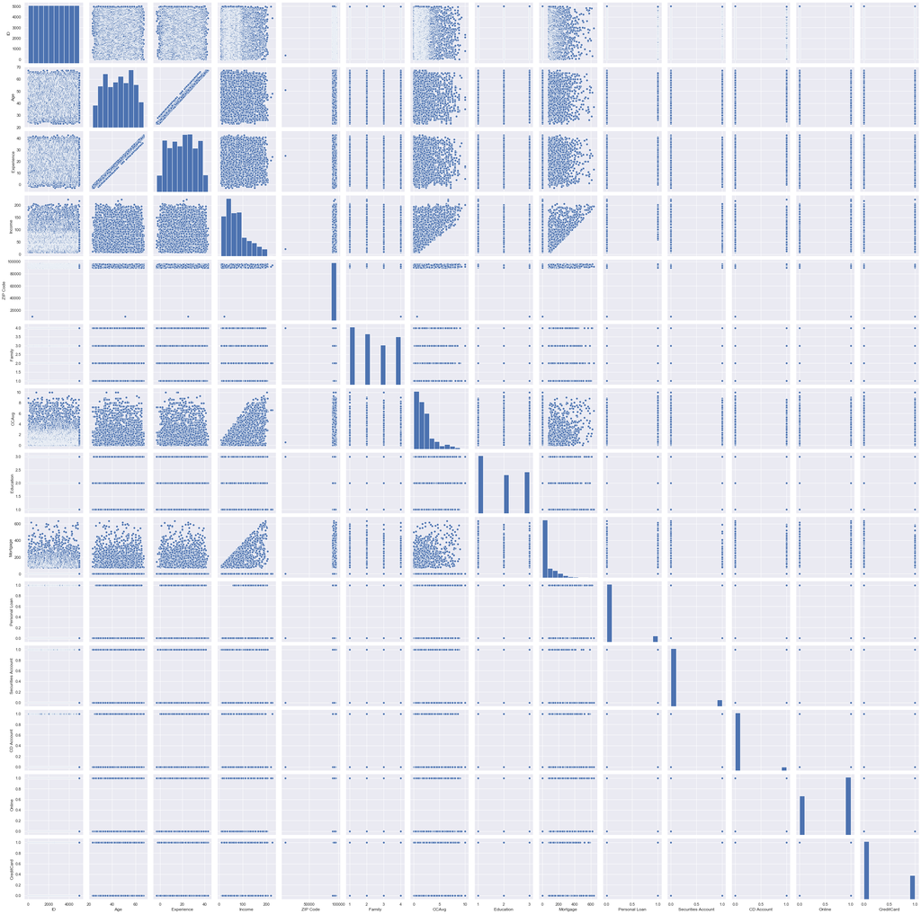

```python
#BIVARIATE
sns.pairplot(data,);
```

```python
# drop the usless ID variable that has no correlation with any other variables
#data=data.drop(['ID'],axis=1)
```

```
                         Age  Experience    Income  ZIP Code    Family  \
Age                 1.000000    0.994215 -0.055269 -0.029216 -0.046418
Experience          0.994215    1.000000 -0.046574 -0.028626 -0.052563
Income             -0.055269   -0.046574  1.000000 -0.016410 -0.157501
ZIP Code           -0.029216   -0.028626 -0.016410  1.000000  0.011778
Family             -0.046418   -0.052563 -0.157501  0.011778  1.000000
CCAvg              -0.052012   -0.050077  0.645984 -0.004061 -0.109275
Education           0.041334    0.013152 -0.187524 -0.017377  0.064929
Mortgage           -0.012539   -0.010582  0.206806  0.007383 -0.020445
Personal Loan      -0.007726   -0.007413  0.502462  0.000107  0.061367
Securities Account -0.000436   -0.001232 -0.002616  0.004704  0.019994
CD Account          0.008043    0.010353  0.169738  0.019972  0.014110
Online              0.013702    0.013898  0.014206  0.016990  0.010354
CreditCard          0.007681    0.008967 -0.002385  0.007691  0.011588

                       CCAvg  Education  Mortgage  Personal Loan  \
Age                -0.052012   0.041334 -0.012539      -0.007726
Experience         -0.050077   0.013152 -0.010582      -0.007413
Income              0.645984  -0.187524  0.206806       0.502462
ZIP Code           -0.004061  -0.017377  0.007383       0.000107
Family             -0.109275   0.064929 -0.020445       0.061367
CCAvg               1.000000  -0.136124  0.109905       0.366889
Education          -0.136124   1.000000 -0.033327       0.136722
Mortgage            0.109905  -0.033327  1.000000       0.142095
Personal Loan       0.366889   0.136722  0.142095       1.000000
Securities Account  0.015086  -0.010812 -0.005411       0.021954
CD Account          0.136534   0.013934  0.089311       0.316355
Online             -0.003611  -0.015004 -0.005995       0.006278
CreditCard         -0.006689  -0.011014 -0.007231       0.002802

                    Securities Account  CD Account    Online  CreditCard
Age                          -0.000436    0.008043  0.013702    0.007681
Experience                   -0.001232    0.010353  0.013898    0.008967
Income                       -0.002616    0.169738  0.014206   -0.002385
ZIP Code                      0.004704    0.019972  0.016990    0.007691
Family                        0.019994    0.014110  0.010354    0.011588
CCAvg                         0.015086    0.136534 -0.003611   -0.006689
Education                    -0.010812    0.013934 -0.015004   -0.011014
Mortgage                     -0.005411    0.089311 -0.005995   -0.007231
Personal Loan                 0.021954    0.316355  0.006278    0.002802
Securities Account            1.000000    0.317034  0.012627   -0.015028
CD Account                    0.317034    1.000000  0.175880    0.278644
Online                        0.012627    0.175880  1.000000    0.004210
CreditCard                   -0.015028    0.278644  0.004210    1.000000
```

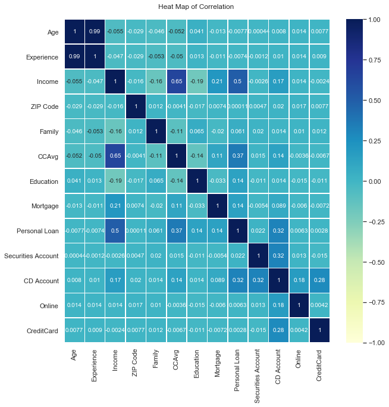

```python
# HEAT MAP
# # Pairplot using

corr = data.corr();
print(corr)
# sns.heatmap(corr, annot = True);

fig, ax = plt.subplots()
fig.set_size_inches(10, 10)

plt.title('Heat Map of Correlation \n')

sns.heatmap(corr,annot=True,cmap='YlGnBu',vmin=-1,vmax=1, linewidths=.5, center=0);
```

Interpretation of correlations Correlations that have a value of more than 0.4 or less than -.4 are considered to be correlated For example Age and Experience have almost a perfect correlation of 0.994 ! The other existing significant correlatation is Income & CCAVe and Income and Personal Loan When plotting logistic or linerar regression we want our variables to be independent, because dependent variables give us well in case of age and experience its almost like one variable, and the result will be overweighted bias towards those 2 We may consider dropping one oe of those for a better weightet fit of independent uncorrelated variables

```python
## Get Data Model Ready

# There are no Null Values hence there is no need to replace them with mean
# the ID column is usless and does not impact our analysis (adds noting in terms of customer buying  a personal loan,
# so it was dropped)
# the categorcal variables such as Personal Loan,Securities Account,CD Account, Online, CreditCard, are either one or zero
# indicating true or false and hence there is no reason to replace them with a mean, as the zero is a valid entry, not a
# missing entry.

#data=data.drop ('ID', axis=1)
data.head(2)
```

|  | Age | Experience | Income | ZIP Code | Family | CCAvg | Education | Mortgage | Personal Loan | Securities Account | CD Account | Online | CreditCard |
| --- | --- | --- | --- | --- | --- | --- | --- | --- | --- | --- | --- | --- | --- |
| 0 | 25 | 1 | 49 | 91107 | 4 | 1.6 | 1 | 0 | 0 | 1 | 0 | 0 | 0 |
| 1 | 45 | 19 | 34 | 90089 | 3 | 1.5 | 1 | 0 | 0 | 1 | 0 | 0 | 0 |

```python
## Splitting Data into training and test
from sklearn.model_selection import train_test_split

# linear model is
# independant variables
X = data.drop(['Personal Loan'], axis=1)

# the dependent variable
y = data['Personal Loan']

X_train, X_test, y_train, y_test = train_test_split(X, y, test_size=0.30,random_state=1)

X_train.head()
```

|  | Age | Experience | Income | ZIP Code | Family | CCAvg | Education | Mortgage | Securities Account | CD Account | Online | CreditCard |
| --- | --- | --- | --- | --- | --- | --- | --- | --- | --- | --- | --- | --- |
| 1334 | 47 | 22 | 35 | 94304 | 2 | 1.3 | 1 | 0 | 0 | 0 | 1 | 0 |
| 4768 | 38 | 14 | 39 | 93118 | 1 | 2.0 | 2 | 0 | 0 | 0 | 1 | 0 |
| 65 | 59 | 35 | 131 | 91360 | 1 | 3.8 | 1 | 0 | 0 | 0 | 1 | 1 |
| 177 | 29 | 3 | 65 | 94132 | 4 | 1.8 | 2 | 244 | 0 | 0 | 0 | 0 |
| 4489 | 39 | 13 | 21 | 95518 | 3 | 0.2 | 2 | 0 | 0 | 0 | 1 | 0 |